# DHS Model Data Guide — Objective 1 (Gender Norms & Health Outcomes)

[figure not shown]

# Introduction

The Demographic and Health Surveys (DHS) Program provides standardized survey data on topics such as fertility, family planning, maternal/child health, and women’s health. The DHS **model datasets** are simplified examples designed for teaching and reproducible demos.

This guide is written as a **teaching resource**: each code chunk includes clear comments, and each section explains *why* the code is being run.

## Research Objective (Objective 1)

**Do markers of gender equity including number of other wives (v505), having a husband as decision-maker related to contraception (v632), and endorsing statements that beating is justified (v744a–v744e) predict (i) domestic violence (D104, D105A–D105N, D106–D108), (ii) decreased contraception use (v312), or (iii) increased risk of STI (v763a) among those who did not have men listening during the DHS interview (v812/v813), compared to those who did?**

## Contents

1. Prepare your data
2. Describe your data (variables + EDA plots)
3. Model your data (survey-weighted logistic regression; stratified + interaction)

# 1) Prepare Your Data

## Install/load packages

Before reading DHS files and running survey-weighted models, load the core packages used in this guide.

```r
# Install packages once if needed:
# install.packages(c("haven","dplyr","tidyverse","ggplot2","scales","survey","broom","janitor"))

library(haven)     # read DHS .DTA files
library(dplyr)     # data wrangling
library(tidyverse) # ggplot2 + tidy tools
library(ggplot2)   # plotting
library(scales)    # percent labels
library(survey)    # survey-weighted analysis
library(broom)     # tidy model output
library(janitor)   # quick frequency tables
```

## Load the dataset

This guide reads the **Individual Recode (IR)** file by default. If your DV/privacy variables are missing in IR, you can switch to **Couples’ Recode (CR)** by changing one line.

```r
# Read IR dataset (default)
dhs <- read_dta("../data/zzir62dt/ZZIR62FL.DTA")

# If IR does not contain the needed DV/privacy variables, switch to CR:
# dhs <- read_dta("../data/zzcr61dt/ZZCR61FL.DTA")

# Confirm dimensions
dim(dhs)
```

```
## [1] 8348 4275
```

## Quick label check (metadata)

DHS variables are often labelled. Checking labels early helps confirm the meaning of each code.

```r
# Print value labels for a few key variables.
# If a variable is missing in your file, R will throw an error here.
dhs$v312[[2]]   # contraception method
```

```
## <labelled<double>[1]>: current contraceptive method
## [1] 0
##
## Labels:
##  value                        label
##      0                    not using
##      1                         pill
##      2                          iud
##      3                   injections
##      4                    diaphragm
##      5                       condom
##      6         female sterilization
##      7           male sterilization
##      8          periodic abstinence
##      9                   withdrawal
##     10                        other
##     11            implants/norplant
##     12                   abstinence
##     13 lactational amenorrhea (lam)
##     14                female condom
##     15                foam or jelly
##     17          other modern method
##     18            specific method 1
##     19            specific method 2
##     20            specific method 3
```

```r
dhs$v505[[2]]   # number of other wives
```

```
## <labelled<double>[1]>: number of other wives
## [1] 0
##
## Labels:
##  value          label
##      0 no other wives
##     98     don't know
```

```r
dhs$v812[[2]]   # privacy indicator
```

```
## <labelled<double>[1]>: presence of husband for 'wife beating justified' questions
## [1] 0
##
## Labels:
##  value               label
##      0                  no
##      1     yes - listening
##      2 yes - not listening
```

```r
dhs$v813[[2]]   # privacy indicator
```

```
## <labelled<double>[1]>: presence of other males for 'wife beating justified' questions
## [1] 0
##
## Labels:
##  value               label
##      0                  no
##      1     yes - listening
##      2 yes - not listening
```

# 2) Describe Your Data (Objective 1)

This section defines **outcomes** and **predictors** required by Objective 1, then shows simple EDA plots to illustrate how variables look.

## Outcomes

### 1) Domestic Violence outcome: D104, D105A–D105N, D106–D108

The DV module is often collected only for a subset of respondents, so it is normal to see a large amount of missing data. The goal here is to (1) show DV missingness, then (2) create a clean binary outcome `dv_any`.

```r
# Step 1: List expected DV items from the DHS recode documentation.
dv_items_expected <- c(
  "d104",
  paste0("d105", letters[1:14]), # d105a ... d105n
  "d106", "d107", "d108"
)

# Step 2: Keep only items that exist in this dataset.
dv_items <- intersect(dv_items_expected, names(dhs))

# Step 3: Summarize missingness for each DV item.
dv_missing <- tibble(var = dv_items) %>%
  mutate(
    n_total = nrow(dhs),
    n_nonmissing = sapply(var, function(v) sum(!is.na(dhs[[v]]))),
    pct_missing = 100 * (1 - n_nonmissing / n_total)
  ) %>%
  arrange(desc(pct_missing))

dv_missing
```

```
## # A tibble: 18 × 4
##    var   n_total n_nonmissing pct_missing
##    <chr>   <int>        <int>       <dbl>
##  1 d105g    8348            0       100
##  2 d105l    8348            0       100
##  3 d105m    8348            0       100
##  4 d105n    8348            0       100
##  5 d105k    8348         2147        74.3
##  6 d108     8348         2147        74.3
##  7 d105e    8348         2148        74.3
##  8 d105f    8348         2148        74.3
##  9 d105h    8348         2148        74.3
## 10 d105i    8348         2148        74.3
## 11 d104     8348         2149        74.3
## 12 d105j    8348         2149        74.3
## 13 d105c    8348         2150        74.2
## 14 d105d    8348         2150        74.2
## 15 d106     8348         2150        74.2
## 16 d105a    8348         2151        74.2
## 17 d105b    8348         2151        74.2
## 18 d107     8348         2151        74.2
```

In DHS-style work, the next step is to build a single DV indicator that is easy to model: “any DV item endorsed”.

```r
# Teaching goal: Create dv_any as a binary outcome:
# - dv_any = 1 if any DV item == 1 ("Yes")
# - dv_any = 0 if DV items observed and none == 1
# - dv_any = NA if the DV module is not observed for that person

# Helper: clean a DV item so that only 0/1 are treated as valid.
# Other codes (e.g., 8 "don't know") are set to NA.
clean_01 <- function(x) {
  x_num <- as.numeric(x)
  x_num <- ifelse(x_num %in% c(0, 1), x_num, NA_real_)
  return(x_num)
}

if (length(dv_items) == 0) {
  # If DV variables are not present, dv_any cannot be constructed.
  message("No DV variables (D104/D105*/D106-D108) found in this dataset file.")
  dhs$dv_any <- NA_integer_
} else {
  # Build a matrix with cleaned 0/1 DV indicators.
  dv_mat <- sapply(dv_items, function(v) clean_01(dhs[[v]]))

  # Count how many DV items are observed (non-missing) per person.
  dv_nonmiss_n <- rowSums(!is.na(dv_mat))

  # Count how many DV items are "Yes" per person.
  dv_yes_n <- rowSums(dv_mat == 1, na.rm = TRUE)

  # Construct dv_any.
  dhs$dv_any <- ifelse(
    dv_nonmiss_n == 0, NA_integer_,           # no DV info at all
    as.integer(dv_yes_n > 0)                  # 1 if any yes else 0
  )

  # Quick frequency table.
  tabyl(dhs$dv_any)
}
```

```
##  dhs$dv_any    n   percent valid_percent
##           0 1114 0.1334451     0.5178987
##           1 1037 0.1242214     0.4821013
##          NA 6197 0.7423335            NA
```

### 2) Contraception use outcome: V312

`v312` is “current contraceptive method.” In DHS coding, `0` usually means “not using”. For Objective 1 we use a simple binary: any method vs none.

```r
# Show raw distribution (useful for teaching before dichotomizing).
table(dhs$v312, useNA = "ifany")
```

```
##
##    0    1    2    3    4    5    6    7    8    9   10   11   13   14   17
## 6496  421   28  829    1   50   23    1    9   11   64  337   63    1   14
```

```r
# Create contraception_use:
# - 1 if v312 != 0 (any method)
# - 0 if v312 == 0
# - NA if v312 missing
dhs$contraception_use <- case_when(
  is.na(dhs$v312) ~ NA_integer_,
  dhs$v312 == 0   ~ 0L,
  TRUE            ~ 1L
)

tabyl(dhs$contraception_use)
```

```
##  dhs$contraception_use    n   percent
##                      0 6496 0.7781505
##                      1 1852 0.2218495
```

### 3) STI risk outcome: V763A

For teaching purposes, keep it simple: use 0/1 as valid responses and treat other codes as missing.

```r
if ("v763a" %in% names(dhs)) {
  # Show raw distribution.
  table(dhs$v763a, useNA = "ifany")

  # Keep only 0/1 and set all other codes to NA.
  dhs$sti_risk_bin <- case_when(
    dhs$v763a %in% c(0, 1) ~ as.integer(dhs$v763a),
    TRUE ~ NA_integer_
  )
} else {
  message("V763A not found in this dataset file.")
  dhs$sti_risk_bin <- NA_integer_
}

tabyl(dhs$sti_risk_bin)
```

```
##  dhs$sti_risk_bin    n     percent valid_percent
##                 0 7397 0.886080498     0.8931418
##                 1  885 0.106013416     0.1068582
##                NA   66 0.007906085            NA
```

## Predictors (gender equity markers + privacy)

### A) Men listening during interview: V812 / V813

Objective 1 compares those **without men listening** vs those **with men listening**.

In this model dataset, the labels typically look like:

- 0 = no
- 1 = yes — listening
- 2 = yes — not listening

For Objective 1, “men listening” means **code 1**. Code 2 counts as **not listening**.

```r
# Create man_listening as a binary:
# - 1 if v812==1 OR v813==1  (a man was listening)
# - 0 if both are in {0,2}   (no man listening, including "present but not listening")
# - NA if both missing or unclear
dhs$man_listening <- case_when(
  (dhs$v812 == 1) | (dhs$v813 == 1) ~ 1L,
  (dhs$v812 %in% c(0, 2) | is.na(dhs$v812)) &
    (dhs$v813 %in% c(0, 2) | is.na(dhs$v813)) ~ 0L,
  TRUE ~ NA_integer_
)

tabyl(dhs$man_listening)
```

```
##  dhs$man_listening    n     percent
##                  0 8326 0.997364638
##                  1   22 0.002635362
```

### B) Number of other wives: V505 (clean 98 = “don’t know”)

Your output shows `v505` includes 98 (“don’t know”). That must be cleaned before modelling; otherwise it is treated like a real count.

```r
# Clean v505 by turning 98 ("don't know") into NA.
dhs$v505_clean <- ifelse(as.numeric(dhs$v505) == 98, NA_real_, as.numeric(dhs$v505))

# Optional binary indicator (any co-wives vs none).
dhs$co_wives_any <- case_when(
  is.na(dhs$v505_clean) ~ NA_integer_,
  dhs$v505_clean > 0    ~ 1L,
  TRUE                  ~ 0L
)

summary(dhs$v505_clean)
```

```
##    Min. 1st Qu.  Median    Mean 3rd Qu.    Max.    NA's
##    0.00    0.00    0.00    0.45    1.00    5.00    3059
```

```r
tabyl(dhs$co_wives_any)
```

```
##  dhs$co_wives_any    n   percent valid_percent
##                 0 3440 0.4120747     0.6504065
##                 1 1849 0.2214902     0.3495935
##                NA 3059 0.3664351            NA
```

### C) Contraception decision-maker: V632 (plus backup marker V822)

Objective 1 mentions `v632`, but in model datasets it can be highly missing because it is asked only in a subset. This guide (1) creates `husband_decider` from `v632` when possible, and (2) creates `v822_bin` as a backup marker with broader coverage.

```r
# ---- V632: primary decision-maker about contraception ----
if ("v632" %in% names(dhs)) {

  # Inspect distribution.
  table(dhs$v632, useNA = "ifany")

  # Create husband_decider.
  # Teaching note: confirm the exact coding using printed labels in your file.
  # A common DHS pattern is "husband/partner" as one category.
  dhs$husband_decider <- case_when(
    dhs$v632 == 2 ~ 1L,                 # husband/partner decides (example coding)
    dhs$v632 %in% c(1, 3, 4, 5) ~ 0L,    # other categories (example)
    TRUE ~ NA_integer_
  )

} else {
  message("V632 not found in this dataset file.")
  dhs$husband_decider <- NA_integer_
}

tabyl(dhs$husband_decider)
```

```
##  dhs$husband_decider    n    percent valid_percent
##                    0  716 0.08576905     0.8201604
##                    1  157 0.01880690     0.1798396
##                   NA 7475 0.89542405            NA
```

```r
# ---- V822: backup gender-norm marker (often broader coverage) ----
if ("v822" %in% names(dhs)) {

  table(dhs$v822, useNA = "ifany")

  # Binary clean: keep 0/1, set other codes to NA.
  dhs$v822_bin <- case_when(
    dhs$v822 %in% c(0, 1) ~ as.integer(dhs$v822),
    TRUE ~ NA_integer_
  )

} else {
  message("V822 not found in this dataset file.")
  dhs$v822_bin <- NA_integer_
}

tabyl(dhs$v822_bin)
```

```
##  dhs$v822_bin    n   percent valid_percent
##             0 1317 0.1577623     0.1809066
##             1 5963 0.7143028     0.8190934
##            NA 1068 0.1279348            NA
```

### D) Endorsing beating is justified: V744A–V744E

These items also include “don’t know” codes (often 8). Treat non 0/1 codes as missing for analysis.

```r
# Clean v744a-v744e to 0/1 only; set other codes to NA.
v744_vars <- c("v744a","v744b","v744c","v744d","v744e")

for (v in v744_vars) {
  if (v %in% names(dhs)) {
    dhs[[paste0(v, "_clean")]] <- clean_01(dhs[[v]])
  }
}

# Create anybeating_justified:
# - 1 if any item == 1
# - 0 if items observed and none == 1
# - NA if no information
clean_vars <- paste0(v744_vars, "_clean")

if (all(clean_vars %in% names(dhs))) {
  mat <- as.matrix(dhs[, clean_vars])
  n_nonmiss <- rowSums(!is.na(mat))
  any_yes <- rowSums(mat == 1, na.rm = TRUE) > 0

  dhs$anybeating_justified <- ifelse(
    n_nonmiss == 0, NA_integer_,
    as.integer(any_yes)
  )
} else {
  message("One or more v744* items missing from this dataset file.")
  dhs$anybeating_justified <- NA_integer_
}

tabyl(dhs$anybeating_justified)
```

```
##  dhs$anybeating_justified    n   percent valid_percent
##                         0 3043 0.3645184      0.374477
##                         1 5083 0.6088884      0.625523
##                        NA  222 0.0265932            NA
```

## EDA plots (Objective 1)

EDA is included to help learners understand each variable before modelling.

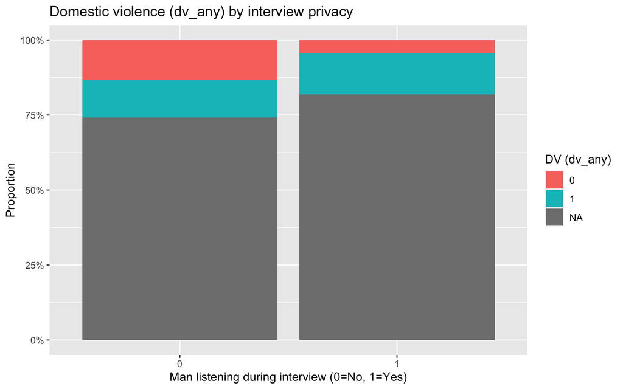

```r
# Outcome distributions by privacy group.
# Position = "fill" makes stacked bars show proportions.

# DV by man listening
ggplot(dhs, aes(x = factor(man_listening), fill = factor(dv_any))) +
  geom_bar(position = "fill") +
  scale_y_continuous(labels = percent) +
  labs(
    x = "Man listening during interview (0=No, 1=Yes)",
    y = "Proportion",
    fill = "DV (dv_any)",
    title = "Domestic violence (dv_any) by interview privacy"
  )
```

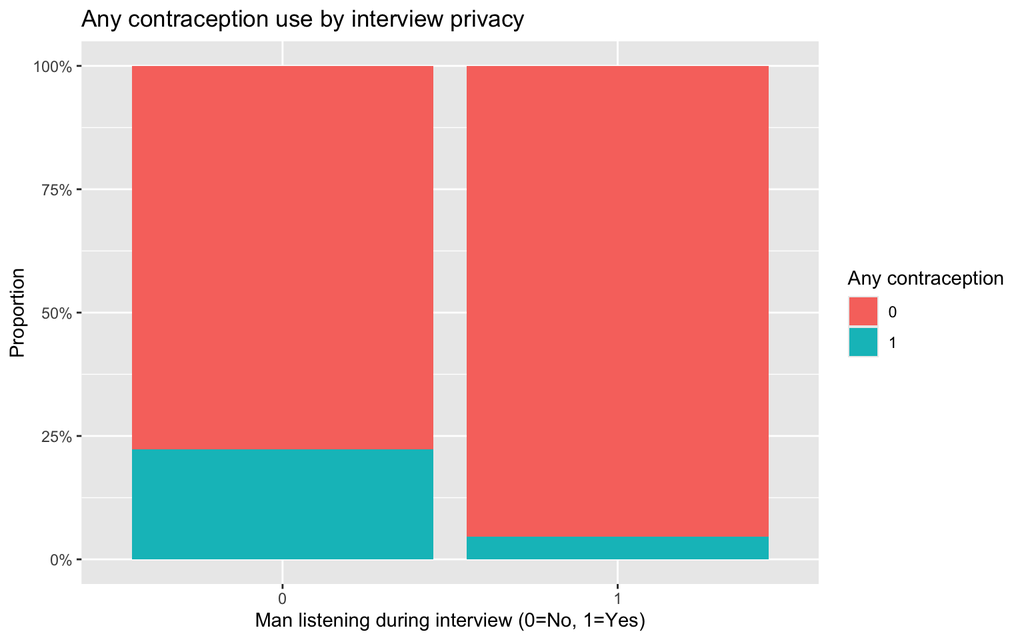

```r
# Contraception by man listening
ggplot(dhs, aes(x = factor(man_listening), fill = factor(contraception_use))) +
  geom_bar(position = "fill") +
  scale_y_continuous(labels = percent) +
  labs(
    x = "Man listening during interview (0=No, 1=Yes)",
    y = "Proportion",
    fill = "Any contraception",
    title = "Any contraception use by interview privacy"
  )
```

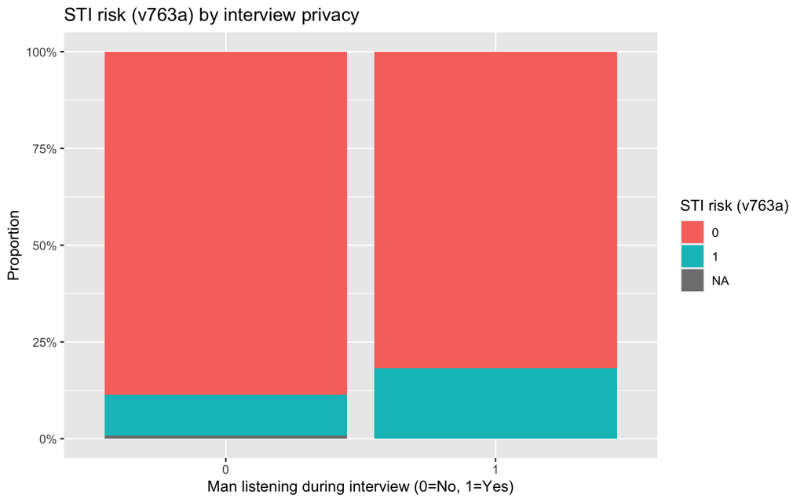

```r
# STI risk by man listening
ggplot(dhs, aes(x = factor(man_listening), fill = factor(sti_risk_bin))) +
  geom_bar(position = "fill") +
  scale_y_continuous(labels = percent) +
  labs(
    x = "Man listening during interview (0=No, 1=Yes)",
    y = "Proportion",
    fill = "STI risk (v763a)",
    title = "STI risk (v763a) by interview privacy"
  )
```

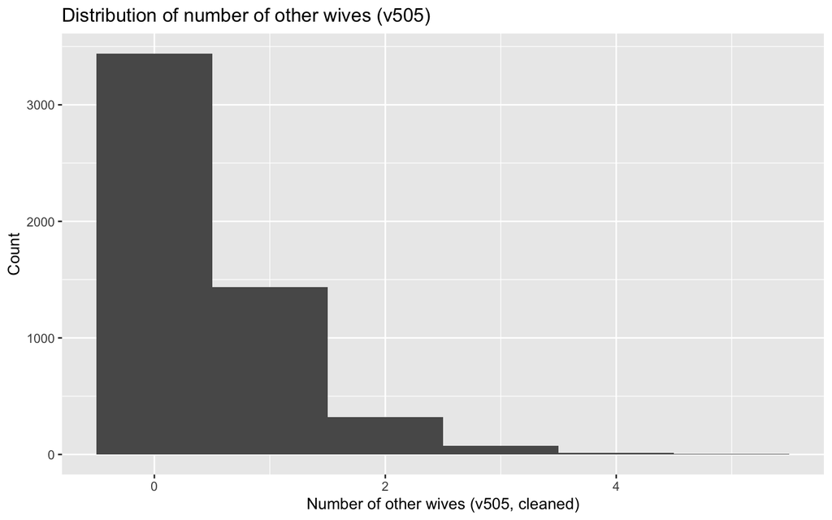

```r
# Predictor distributions.

# v505_clean histogram (exclude extreme/unknown values by cleaning first).
ggplot(dhs, aes(x = v505_clean)) +
  geom_histogram(binwidth = 1) +
  labs(
    x = "Number of other wives (v505, cleaned)",
    y = "Count",
    title = "Distribution of number of other wives (v505)"
  )
```

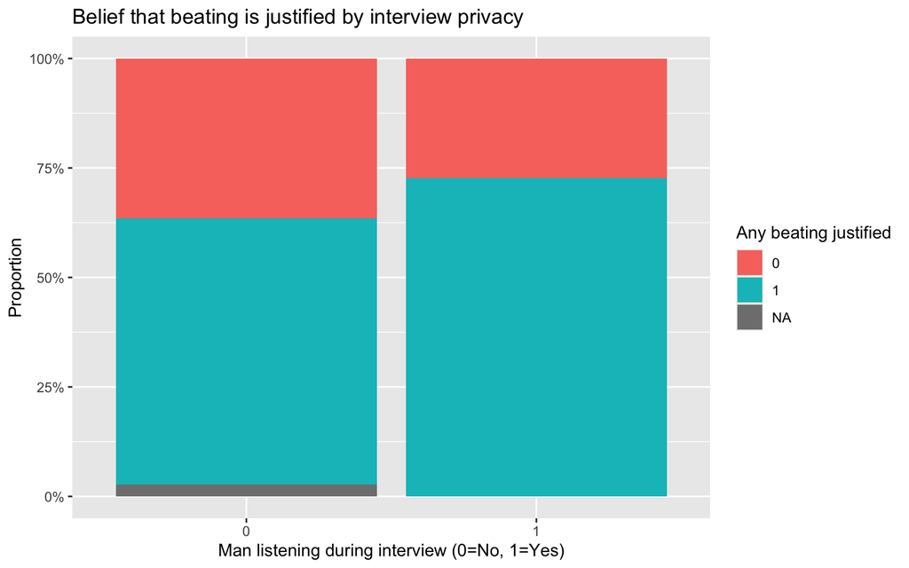

```r
# Beating justified by man listening.
ggplot(dhs, aes(x = factor(man_listening), fill = factor(anybeating_justified))) +
  geom_bar(position = "fill") +
  scale_y_continuous(labels = percent) +
  labs(
    x = "Man listening during interview (0=No, 1=Yes)",
    y = "Proportion",
    fill = "Any beating justified",
    title = "Belief that beating is justified by interview privacy"
  )
```

# 3) Model Your Data (Objective 1)

Objective 1 requires two key ideas:

1. **Survey-weighted regression** (DHS uses weights, clustering, and stratification).
2. **Comparison by privacy** (fit models separately by `man_listening`, and also fit an interaction model).

A practical teaching note from your dataset:

- The `man_listening = 1` group is very small, and DV is observed for only a handful of those cases.
- For DV, a stratified regression may be impossible due to **0 complete cases**. This guide handles that safely and prints a clear message instead of crashing.

### Survey design object

```r
# Create analysis weight from v005 (DHS stores 6 implied decimals).
dhs$wt <- dhs$v005 / 1000000

# Handle "lonely PSU" strata (one PSU in a stratum), which can otherwise throw an error.
options(survey.lonely.psu = "adjust")

# Create survey design:
# - v021: PSU / cluster
# - v022: strata
# - wt: sampling weights
des <- svydesign(
  ids = ~v021,
  strata = ~v022,
  weights = ~wt,
  data = dhs,
  nest = TRUE
)
```

### Helper functions for teaching output

First, convert regression coefficients to odds ratios. Second, fit models safely even when a subgroup has no usable rows.

```r
# Convert svyglm coefficients (log-odds) to odds ratios + 95% CI.
tidy_or <- function(fit) {
  broom::tidy(fit) %>%
    mutate(
      OR = exp(estimate),
      CI_low = exp(estimate - 1.96 * std.error),
      CI_high = exp(estimate + 1.96 * std.error)
    ) %>%
    select(term, OR, CI_low, CI_high, p.value)
}

# Safe wrapper to prevent svyglm from crashing when a subset has 0 usable rows.
safe_svyglm_or <- function(formula, design, label) {
  mf <- model.frame(formula, data = design$variables, na.action = na.omit)

  # If no complete cases remain, return a clear note.
  if (nrow(mf) == 0) {
    return(tibble(note = paste0(label, ": skipped (0 complete cases after NA removal).")))
  }

  # If the outcome has no variation (all 0 or all 1), regression is not meaningful.
  if (length(unique(mf[[1]])) < 2) {
    return(tibble(note = paste0(label, ": skipped (outcome has no variation in this subset).")))
  }

  fit <- svyglm(formula, design = design, family = quasibinomial())
  tidy_or(fit)
}
```

### Choose the decision-maker marker for modelling

Objective 1 references `v632`, but in this model dataset `husband_decider` can be extremely sparse. For a stable teaching demo, default to `v822_bin` unless `husband_decider` has sufficient non-missing data.

```r
# Teaching rule:
# - If husband_decider exists but is very sparse, v822_bin is the better modelling choice.
# - This still aligns with the objective because both represent gender-norm decision dynamics.

n_husband_decider <- sum(!is.na(dhs$husband_decider))
n_v822 <- sum(!is.na(dhs$v822_bin))

tibble(
  n_nonmissing_husband_decider = n_husband_decider,
  n_nonmissing_v822_bin = n_v822
)
```

```
## # A tibble: 1 × 2
##   n_nonmissing_husband_decider n_nonmissing_v822_bin
##                          <int>                 <int>
## 1                          873                  7280
```

```r
# Practical default for this model dataset:
use_decider <- "v822_bin"
use_decider
```

```
## [1] "v822_bin"
```

### Create stratified survey designs

```r
# Two designs for comparing privacy groups.
des_no  <- subset(des, man_listening == 0)  # no man listening
des_yes <- subset(des, man_listening == 1)  # man listening
```

### Feasibility check for DV by privacy group

This small table explains why DV stratified models can fail: DV is observed for very few cases when `man_listening = 1`.

```r
# Count DV observed vs missing by man_listening group.
dhs %>%
  mutate(dv_observed = !is.na(dv_any)) %>%
  count(man_listening, dv_observed) %>%
  tidyr::pivot_wider(names_from = dv_observed, values_from = n, values_fill = 0) %>%
  rename(DV_missing = `FALSE`, DV_observed = `TRUE`)
```

```
## # A tibble: 2 × 3
##   man_listening DV_missing DV_observed
##           <int>      <int>       <int>
## 1             0       6179        2147
## 2             1         18           4
```

## A) Stratified survey-weighted logistic regression

In each stratified model, the predictors are:

- `v505_clean` (number of other wives; 98 removed)
- `use_decider` (default: `v822_bin`)
- `anybeating_justified` (binary)

### Outcome 1: Domestic violence (dv_any)

```r
# DV model formula.
# Use v505_clean (not v505) so "98 = don't know" does not act like a real count.
form_dv <- as.formula(
  paste0("dv_any ~ v505_clean + ", use_decider, " + anybeating_justified")
)

# Fit stratified models safely.
# If a subgroup has 0 complete cases, the function returns a teaching note instead of crashing.
safe_svyglm_or(form_dv, des_no,  "DV | man_listening = No")
```

```
## # A tibble: 4 × 5
##   term                    OR CI_low CI_high  p.value
##   <chr>                <dbl>  <dbl>   <dbl>    <dbl>
## 1 (Intercept)          0.713  0.494    1.03 0.0728
## 2 v505_clean           1.03   0.880    1.20 0.723
## 3 v822_bin             0.979  0.693    1.38 0.905
## 4 anybeating_justified 1.67   1.29     2.16 0.000128
```

```r
safe_svyglm_or(form_dv, des_yes, "DV | man_listening = Yes")
```

```
## # A tibble: 3 × 5
##   term                      OR   CI_low CI_high p.value
##   <chr>                  <dbl>    <dbl>   <dbl>   <dbl>
## 1 (Intercept)          1.05e+9 1.48e+ 8 7.46e+9     NaN
## 2 v505_clean           1.04e+0 6.48e- 2 1.66e+1     NaN
## 3 anybeating_justified 1.99e-9 6.04e-11 6.57e-8     NaN
```

### Outcome 2: Any contraception use (contraception_use)

```r
# Contraception model formula.
form_contra <- as.formula(
  paste0("contraception_use ~ v505_clean + ", use_decider, " + anybeating_justified")
)

# Fit stratified models safely.
safe_svyglm_or(form_contra, des_no,  "Contraception | man_listening = No")
```

```
## # A tibble: 4 × 5
##   term                    OR CI_low CI_high  p.value
##   <chr>                <dbl>  <dbl>   <dbl>    <dbl>
## 1 (Intercept)          0.169  0.123   0.233 1.43e-21
## 2 v505_clean           0.768  0.663   0.889 5.16e- 4
## 3 v822_bin             1.67   1.24    2.24  8.61e- 4
## 4 anybeating_justified 0.969  0.751   1.25  8.06e- 1
```

```r
safe_svyglm_or(form_contra, des_yes, "Contraception | man_listening = Yes")
```

```
## # A tibble: 4 × 5
##   term                       OR   CI_low  CI_high  p.value
##   <chr>                   <dbl>    <dbl>    <dbl>    <dbl>
## 1 (Intercept)          1.31e-18 4.27e-20 4.04e-17 0.000168
## 2 v505_clean           3.49e-10 1.65e-11 7.39e- 9 0.000792
## 3 v822_bin             1.30e+ 9 6.02e+ 7 2.79e+10 0.000899
## 4 anybeating_justified 6.61e+ 8 2.76e+ 7 1.58e+10 0.00110
```

### Outcome 3: STI risk (sti_risk_bin)

```r
# STI risk model formula.
form_sti <- as.formula(
  paste0("sti_risk_bin ~ v505_clean + ", use_decider, " + anybeating_justified")
)

# Fit stratified models safely.
safe_svyglm_or(form_sti, des_no,  "STI risk | man_listening = No")
```

```
## # A tibble: 4 × 5
##   term                    OR CI_low CI_high  p.value
##   <chr>                <dbl>  <dbl>   <dbl>    <dbl>
## 1 (Intercept)          0.108 0.0669   0.175 1.54e-16
## 2 v505_clean           1.21  1.04     1.40  1.25e- 2
## 3 v822_bin             1.37  0.962    1.95  8.23e- 2
## 4 anybeating_justified 0.809 0.590    1.11  1.91e- 1
```

```r
safe_svyglm_or(form_sti, des_yes, "STI risk | man_listening = Yes")
```

```
## # A tibble: 4 × 5
##   term                     OR CI_low CI_high p.value
##   <chr>                 <dbl>  <dbl>   <dbl>   <dbl>
## 1 (Intercept)          0.0890 0.0111   0.716   0.107
## 2 v505_clean           1.44   0.224    9.20    0.728
## 3 v822_bin             1.95   0.0557  68.4     0.737
## 4 anybeating_justified 0.529  0.0421   6.64    0.655
```

## B) Interaction models (formal “difference by privacy” test)

Stratified models are easiest to read side-by-side. Interaction models provide a formal test of whether associations differ when a man is listening.

### Interaction model for DV

```r
# DV interaction model:
# dv_any ~ (predictors) * man_listening
form_dv_int <- as.formula(
  paste0("dv_any ~ (v505_clean + ", use_decider, " + anybeating_justified) * man_listening")
)

# Fit safely to avoid crashes if DV is too sparse.
safe_svyglm_or(form_dv_int, des, "DV interaction model (full sample)")
```

```
## # A tibble: 7 × 5
##   term                                    OR  CI_low CI_high  p.value
##   <chr>                                <dbl>   <dbl>   <dbl>    <dbl>
## 1 (Intercept)                        7.13e-1 4.94e-1 1.03e+0 7.28e- 2
## 2 v505_clean                         1.03e+0 8.80e-1 1.20e+0 7.23e- 1
## 3 v822_bin                           9.79e-1 6.93e-1 1.38e+0 9.05e- 1
## 4 anybeating_justified               1.67e+0 1.29e+0 2.16e+0 1.28e- 4
## 5 man_listening                      1.31e+6 1.84e+5 9.31e+6 5.68e-31
## 6 v505_clean:man_listening           1.01e+0 6.31e-2 1.61e+1 9.96e- 1
## 7 anybeating_justified:man_listening 1.35e-6 4.01e-8 4.51e-5 2.04e-12
```

### Interaction model for contraception

```r
form_contra_int <- as.formula(
  paste0("contraception_use ~ (v505_clean + ", use_decider, " + anybeating_justified) * man_listening")
)

safe_svyglm_or(form_contra_int, des, "Contraception interaction model (full sample)")
```

```
## # A tibble: 8 × 5
##   term                                     OR   CI_low  CI_high  p.value
##   <chr>                                 <dbl>    <dbl>    <dbl>    <dbl>
## 1 (Intercept)                        1.69e- 1 1.23e- 1 2.33e- 1 1.76e-21
## 2 v505_clean                         7.68e- 1 6.63e- 1 8.89e- 1 5.19e- 4
## 3 v822_bin                           1.67e+ 0 1.24e+ 0 2.24e+ 0 8.64e- 4
## 4 anybeating_justified               9.69e- 1 7.51e- 1 1.25e+ 0 8.06e- 1
## 5 man_listening                      9.65e-12 3.13e-13 2.98e-10 3.29e-32
## 6 v505_clean:man_listening           5.06e- 7 2.35e- 8 1.09e- 5 5.74e-17
## 7 v822_bin:man_listening             6.99e+ 5 3.23e+ 4 1.51e+ 7 3.94e-15
## 8 anybeating_justified:man_listening 6.11e+ 5 2.53e+ 4 1.47e+ 7 4.00e-14
```

### Interaction model for STI risk

```r
form_sti_int <- as.formula(
  paste0("sti_risk_bin ~ (v505_clean + ", use_decider, " + anybeating_justified) * man_listening")
)

safe_svyglm_or(form_sti_int, des, "STI interaction model (full sample)")
```

```
## # A tibble: 8 × 5
##   term                                  OR CI_low CI_high  p.value
##   <chr>                              <dbl>  <dbl>   <dbl>    <dbl>
## 1 (Intercept)                        0.108 0.0669   0.175 1.74e-16
## 2 v505_clean                         1.21  1.04     1.40  1.25e- 2
## 3 v822_bin                           1.37  0.962    1.95  8.23e- 2
## 4 anybeating_justified               0.809 0.590    1.11  1.91e- 1
## 5 man_listening                      0.822 0.0940   7.20  8.60e- 1
## 6 v505_clean:man_listening           1.19  0.186    7.58  8.55e- 1
## 7 v822_bin:man_listening             1.42  0.0406  50.0   8.46e- 1
## 8 anybeating_justified:man_listening 0.653 0.0513   8.32  7.43e- 1
```

# Plots for model results

## Save model outputs

```r
# Save OR tables (these objects will be used for plotting)
or_dv_no  <- safe_svyglm_or(form_dv,     des_no,  "DV | man_listening = No")
or_dv_yes <- safe_svyglm_or(form_dv,     des_yes, "DV | man_listening = Yes")

or_contra_no  <- safe_svyglm_or(form_contra, des_no,  "Contraception | man_listening = No")
or_contra_yes <- safe_svyglm_or(form_contra, des_yes, "Contraception | man_listening = Yes")

or_sti_no  <- safe_svyglm_or(form_sti, des_no,  "STI risk | man_listening = No")
or_sti_yes <- safe_svyglm_or(form_sti, des_yes, "STI risk | man_listening = Yes")
```

## Forest plot

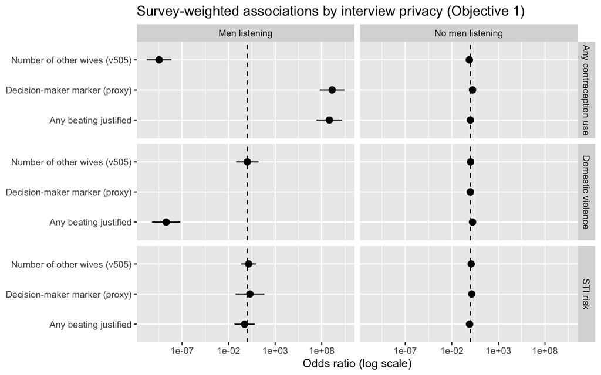

```r
# Combine results into one plotting data frame
plot_df <- bind_rows(
  or_dv_no  %>% mutate(outcome = "Domestic violence", group = "No men listening"),
  or_dv_yes %>% mutate(outcome = "Domestic violence", group = "Men listening"),
  or_contra_no  %>% mutate(outcome = "Any contraception use", group = "No men listening"),
  or_contra_yes %>% mutate(outcome = "Any contraception use", group = "Men listening"),
  or_sti_no  %>% mutate(outcome = "STI risk", group = "No men listening"),
  or_sti_yes %>% mutate(outcome = "STI risk", group = "Men listening")
) %>%
  filter(term != "(Intercept)") %>%               # intercept not plotted
  mutate(term = recode(term,                      # nicer labels (optional)
                       v505_clean = "Number of other wives (v505)",
                       v822_bin = "Decision-maker marker (proxy)",
                       anybeating_justified = "Any beating justified"))

# Forest plot (log scale is standard for ORs)
ggplot(plot_df, aes(x = term, y = OR, ymin = CI_low, ymax = CI_high)) +
  geom_pointrange() +
  geom_hline(yintercept = 1, linetype = "dashed") +
  scale_y_log10() +
  coord_flip() +
  facet_grid(outcome ~ group) +
  labs(
    x = NULL,
    y = "Odds ratio (log scale)",
    title = "Survey-weighted associations by interview privacy (Objective 1)"
  )
```

# Results interpretation

All models are **survey-weighted logistic regressions**. Results are reported as **odds ratios (OR)** with **95% confidence intervals (CI)**. OR > 1 means higher odds of the outcome; OR < 1 means lower odds.

### Feasibility note (Domestic Violence and “men listening”)

The DV module has **structural missingness** (only asked to a subset, often dependent on privacy). In this dataset, the subgroup with **`man_listening = 1` is extremely small**, especially for DV, so models in that subgroup are **unstable** (very large/small ORs, `NaN` p-values). Those estimates should be treated as **not interpretable**. The most meaningful comparisons come from the **`man_listening = 0`** group.

### Outcome 1: Domestic violence (dv_any)

**When `man_listening = 0` (no man listening):**

- **Any beating justified** is associated with **higher odds of DV** (OR = 1.67, 95% CI 1.29–2.16). Interpretation: holding other predictors constant, endorsing any justification corresponds to about **67% higher odds** of reporting DV.
- **Number of other wives (v505)** shows **no clear association** with DV.
- The **decision-maker proxy (v822_bin)** shows **no clear association** with DV.

**When `man_listening = 1` (man listening):**

- Results are **not reliable** due to extremely small usable sample size.

### Outcome 2: Any contraception use (contraception_use)

**When `man_listening = 0`:**

- **More co-wives (v505)** is associated with **lower odds of contraception use** (OR = 0.77, 95% CI 0.66–0.89). Interpretation: each +1 in v505 corresponds to roughly **23% lower odds** of using contraception, holding other predictors constant.
- **v822_bin** is associated with **higher odds of contraception use** (OR = 1.67, 95% CI 1.24–2.24).
- **Any beating justified** shows **no clear association** with contraception use.

**When `man_listening = 1`:**

- Estimates are **unstable** (tiny subgroup), so they should not be interpreted.

**Interaction model (formal test of “difference by privacy”):**

- The interaction model is also **unstable** for contraception because `man_listening = 1` is so rare. Treat this mainly as a **teaching example** of why feasibility checks matter.

### Outcome 3: STI risk (sti_risk_bin)

**When `man_listening = 0`:**

- **More co-wives (v505)** is associated with **higher odds of STI risk** (OR = 1.21, 95% CI 1.04–1.40).
- **v822_bin** is **suggestive** but not clearly significant (OR = 1.37, 95% CI 0.96–1.95).
- **Any beating justified** shows **no clear association** with STI risk.

**When `man_listening = 1`:**

- Estimates are **imprecise** (wide CIs), consistent with limited data.

**Interaction model:**

- There is **no strong evidence** that the associations differ by privacy status for STI risk (interaction terms not clearly different from 0).